# Correlation between Primary Tumor Location and Age in nonsmokers

BSMS222 Jihyun Seo(2015250126)

## 1. Introduction

In resource paper ‘Proteogenomics of Non-smoking Lung Cancer in East Asia Delineates Molecular Signature of Pathogenesis and Progression’, focusing on clinical data from Taiwan(TW) cohort, what I was wondering is about primary tumor location in treatment-naive patients from TW, especially whose histology type is ADC(adenocacinoma) and who are nonsmokers. Which factor among paients’ characters such as age, gender, ADC stage or EGFR_status would have correlation to tumor location?

## 2. Dataset $ Visualizing

```r
library(dplyr)
library(ggplot2)
library(readxl)
library(tidyverse)
```

```r
d1 <- read_excel("mmc1.xlsx", sheet = "Table S1A_clinical_103patient")
head(d1)
```

| ID | Proteome_Batch | Gender | Age | Smoking Status | Histology Type | Stage | EGFR_Status | Primary Tumor Location |
| --- | --- | --- | --- | --- | --- | --- | --- | --- |
| P002 | B01-2 | Male | 73.77687 | Nonsmoke | ADC | IB | others | LUL |
| P004 | B01-4 | Female | 52.97741 | Nonsmoke | SCC | IA | exon19del | RLL |
| P005 | B02-1 | Male | 72.75017 | Current_Smoker | SCC | IA | WT | LUL |
| P006 | B02-2 | Female | 46.86105 | Nonsmoke | ADC | IB | WT | RLL |
| P007 | B02-3 | Male | 67.40589 | Nonsmoke | ADC | IIA | WT | RLL |
| P009 | B03-1 | Female | 53.80424 | Nonsmoke | ADC | IIA | L858R | LLL |

First of all, select data of only nonsmokers and ADC patients from the clinical data source given from paper. And select 4 factors(Gender, Age, Stge, EGFR_Status) to focus on them.

```r
d2 <- d1 %>%
  filter(`Smoking Status` == 'Nonsmoke', `Histology Type` == "ADC") %>%
  select('Gender', 'Age', 'Stage', 'EGFR_Status', 'Primary Tumor Location')
d2
```

| Gender | Age | Stage | EGFR_Status | Primary Tumor Location |
| --- | --- | --- | --- | --- |
| Male | 73.77687 | IB | others | LUL |
| Female | 46.86105 | IB | WT | RLL |
| Male | 67.40589 | IIA | WT | RLL |
| Female | 53.80424 | IIA | L858R | LLL |
| Female | 56.47912 | IB | exon19del | LUL |
| Male | 59.02259 | IA | exon19del | RLL |
| Male | 61.85900 | IB | exon19del | LLL |
| Female | 44.91444 | IA | WT | RML |
| Female | 54.19576 | IA | exon19del | RLL |
| Male | 59.82752 | IA | exon19del | RUL |

[output cut: 69 more lines]

Let’s make plot for four points of view 1) gender and tumor location 2) stage and tumor location 3) EGFR_Status and tumor location 4) age and tumor location.

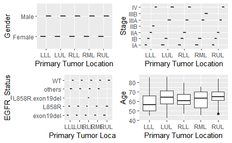

```r
p1 <- d2 %>% ggplot(aes(`Primary Tumor Location`, Gender)) +
  geom_boxplot()
p2 <- d2 %>% ggplot(aes(`Primary Tumor Location`, Stage)) +
  geom_boxplot()
p3 <- d2 %>% ggplot(aes(`Primary Tumor Location`, EGFR_Status)) +
  geom_boxplot()
p4 <- d2 %>% ggplot(aes(`Primary Tumor Location`, Age)) +
  geom_boxplot()

plot_grid(p1, p2, p3, p4)
```

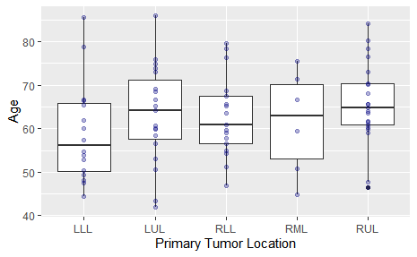

```r
d2 %>% ggplot(aes(`Primary Tumor Location`, Age)) +
  geom_boxplot() +
  geom_point(alpha=0.3, size = 1.4, color='navy')
```

## 4. Reference

Yi-JuChen, Theodoros I.Roumeliotis, Ya-Hsuan Chang, Ching-Tai Chen, Chia-Li Han, Miao-Hsia Lin, Huei-Wen Chen , Gee-Chen Chang, Yih-Leong Chang, Chen-Tu Wu, Mong-Wei Lin, Min-Shu Hsieh, Yu-Tai Wang, Yet-Ran Chen, Inge Jonassen, Fatemeh Zamanzad Ghavidel, Ze-Shiang Lin, Kuen-Tyng Lin1 …Yu-Ju Chen, Proteogenomics of Non-smoking Lung Cancer in East Asia Delineates Molecular Signatures of Pathogenesis and Progression, Cell, Volume 182, Issue 1, 9 July 2020, Pages 226-244.e17